# Machine Learning Week 4 Assignment

## Background

Using devices such as Jawbone Up, Nike FuelBand, and Fitbit it is now possible to collect a large amount of data about personal activity relatively inexpensively. These type of devices are part of the quantified self movement - a group of enthusiasts who take measurements about themselves regularly to improve their health, to find patterns in their behavior, or because they are tech geeks. One thing that people regularly do is quantify how much of a particular activity they do, but they rarely quantify how well they do it. In this project, your goal will be to use data from accelerometers on the belt, forearm, arm, and dumbell of 6 participants. They were asked to perform barbell lifts correctly and incorrectly in 5 different ways. More information is available from the website here: http://groupware.les.inf.puc-rio.br/har (see the section on the Weight Lifting Exercise Dataset).

## Data

The training data for this project are available here:

https://d396qusza40orc.cloudfront.net/predmachlearn/pml-training.csv

The test data are available here:

https://d396qusza40orc.cloudfront.net/predmachlearn/pml-testing.csv

## Libraries

```r
library(caret)
library(mlbench)
library(randomForest)
```

## Loading daata

```r
indata <- read.csv("pml-training.csv")
testing <- read.csv("pml-testing.csv")
```

## Data Preparation

### Clearning up the data and Feature Selection

```r
##filtering columns containing only Na
indata <- indata[, colSums(is.na(testing)) != nrow(testing)]
testing <- testing[, colSums(is.na(testing)) != nrow(testing)]
##Removing unnecessary columns
indata <- indata[,-(1:7)]

#Reducing pair-wise correlation.
correlationMatrix <- cor(indata[, -dim(indata)[2]])
highlyCorrelated <- findCorrelation(correlationMatrix, cutoff=0.75)
indata <- indata[, -highlyCorrelated]
```

After removing highly correlated variables, we now have 31 features to train our models.

### Training Validation split

We split the data a 70%-30% split to training and validation respectively to get the expected out-of-sample error.

```r
#Spliting data into training and validation
set.seed(123)
inTrain <- createDataPartition(y=indata$classe, p=0.7, list=F)
training <- indata[inTrain, ]
validation <- indata[-inTrain, ]
```

### Training the Model

Training a random forest model with all of the features.

```r
#Using Random Forest
#Use 3-fold CV to select best  parameters
control <- trainControl(method="cv", number=3, verboseIter=F)
model_rf <- train(classe~., data=training, method="rf",  trControl=control)


model_rf$finalModel
```

```
##
## Call:
##  randomForest(x = x, y = y, mtry = param$mtry)
##                Type of random forest: classification
##                      Number of trees: 500
## No. of variables tried at each split: 2
##
##         OOB estimate of  error rate: 0.79%
## Confusion matrix:
##      A    B    C    D    E class.error
## A 3902    2    0    0    2 0.001024066
## B   14 2634   10    0    0 0.009029345
## C    2   22 2364    8    0 0.013355593
## D    1    0   37 2211    3 0.018206039
## E    0    1    1    6 2517 0.003168317
```

### Tesing the model on the validation set.

```r
predictions <- predict(model_rf, newdata=validation)

confusionMatrix(validation$classe, predictions)
```

```
## Confusion Matrix and Statistics
##
##           Reference
## Prediction    A    B    C    D    E
##          A 1672    1    0    1    0
##          B    6 1131    2    0    0
##          C    1   16 1002    7    0
##          D    0    0   21  942    1
##          E    0    3    0    0 1079
##
## Overall Statistics
##
##                Accuracy : 0.99
##                  95% CI : (0.9871, 0.9924)
##     No Information Rate : 0.2853
##     P-Value [Acc > NIR] : < 2.2e-16
##
##                   Kappa : 0.9873
##  Mcnemar's Test P-Value : NA
##
## Statistics by Class:
##
##                      Class: A Class: B Class: C Class: D Class: E
## Sensitivity            0.9958   0.9826   0.9776   0.9916   0.9991
## Specificity            0.9995   0.9983   0.9951   0.9955   0.9994
## Pos Pred Value         0.9988   0.9930   0.9766   0.9772   0.9972
## Neg Pred Value         0.9983   0.9958   0.9953   0.9984   0.9998
## Prevalence             0.2853   0.1956   0.1742   0.1614   0.1835
## Detection Rate         0.2841   0.1922   0.1703   0.1601   0.1833
## Detection Prevalence   0.2845   0.1935   0.1743   0.1638   0.1839
## Balanced Accuracy      0.9977   0.9905   0.9863   0.9936   0.9992
```

The accuracy on the validation set is 99%, thus the expected for the out-of-sample error is 1%.

### Ranking Important Features

```r
importance <- varImp(model_rf, scale=FALSE)
# summarize importance
print(importance)
```

```
## rf variable importance
##
##   only 20 most important variables shown (out of 31)
##
##                      Overall
## yaw_belt               770.2
## magnet_dumbbell_z      607.3
## magnet_belt_y          561.8
## pitch_forearm          556.2
## roll_forearm           494.6
## roll_dumbbell          478.1
## roll_arm               408.5
## gyros_belt_z           390.3
## yaw_dumbbell           381.8
## total_accel_dumbbell   376.3
## gyros_dumbbell_y       369.1
## accel_forearm_x        357.2
## magnet_arm_x           345.6
## pitch_dumbbell         340.3
## magnet_forearm_z       339.8
## accel_forearm_z        327.2
## magnet_belt_x          324.9
## magnet_forearm_y       317.6
## yaw_arm                306.5
## magnet_forearm_x       306.1
```

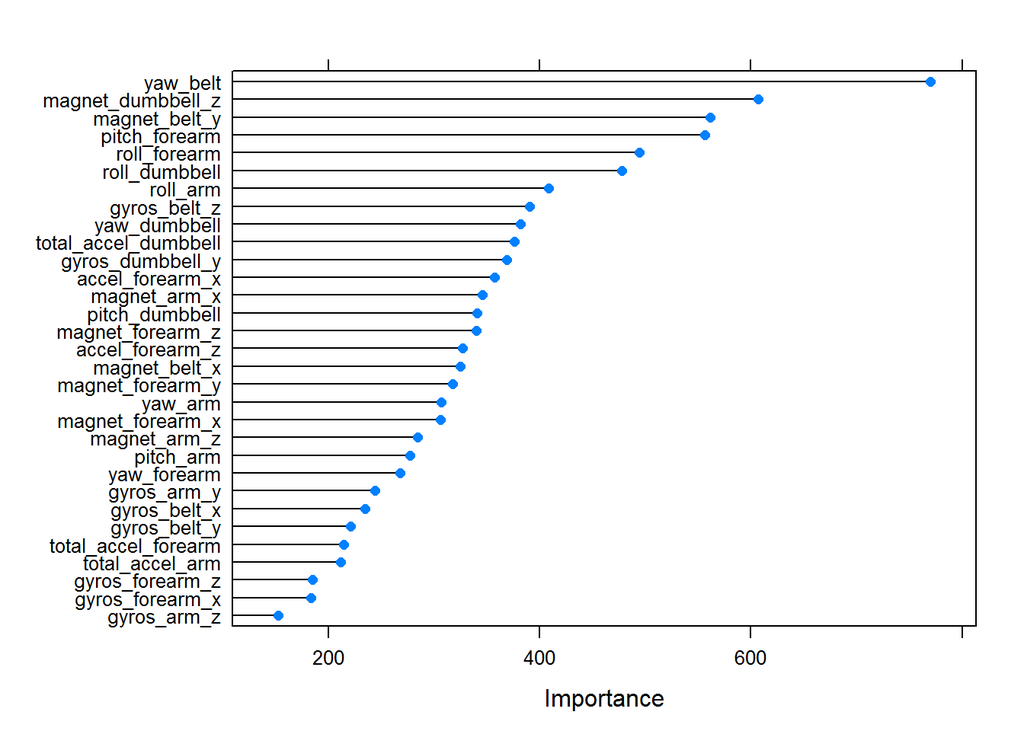

```r
# plot importance
plot(importance)
```

## Predicting Test set

```r
predictions <- predict(model_rf, testing)
predictions
```

```
##  [1] B A B A A E D B A A B C B A E E A B B B
## Levels: A B C D E
```